# An example workflow of building energy model calibration

Hongyuan Jia

Adrian Chong

2021-03-17

# Workflow

- The model we choose with brief description

# Create synthetic meter data

- Read the original baseline model
- Define observed inputs, outputs and calibration parameters
- Run simulation to create synthetic data

## Read original baseline model

First, we read the baseline model using the `eplusr::read_idf()` function.

```r
# path of the baseline model
path_base <- here("data-raw/idf/Singapore_Concrete_Benchmark_Model.idf")

# read baseline model
base <- read_idf(path_base)
```

```r
# remove all existing outputs
base$`Output:Variable` <- NULL
base$`Output:Meter:MeterFileOnly` <- NULL
```

## Observed inputs, outputs and calibration parameters

We choose AMY (Annual Meteorological Year) as the observed input. According to Fig.5 in our paper, AMY together with other separate local weather variables are commonly used as the observed inputs for calibration.

For calibration parameters, we select 6 most commonly used ones from Fig. 6 of our paper for demonstration, including:

- Material properties
- Infiltration rate
- Occupancy density
- Lighting power density
- Electric equipment power density
- Cooling setpoint

The mapping between those parameters and corresponding EnergyPlus inputs for the baseline model are listed in the table blow:

| Calibration parameter | Class | Object | Field | Value |
| --- | --- | --- | --- | --- |
| Material properties | `Material` | `SGP_Concrete_200mm` | `Conductivity {W/m-K}` | 1.442 |
|  |  |  | `Density {kg/m3}` | 2400 |
|  |  |  | `Specific Heat {J/kg-K}` | 832 |
| Infiltration rate | `ZoneInfiltration:DesignFlowRate` | All `*_Infiltration` objects for offices | `Air Changes per Hour {1/hr}` | 0.2 |
| Occupancy density | `People` | All objects for offices | `Zone Floor Area per Person {m2/persion}` | 10 |
| Lighting power density | `Lights` | All `*_Lights` objects for offices | `Watts per Zone Floor Area {W/m2}` | 15 |
| Electric equipment power sensity | `ElectricEquipment` | All `*_Equip` objects for offices | `Watts per Zone Floor Area {W/m2}` | 14 |
| Cooling setpoint | `Schedule:Compact` | `Sch_Zone_Cooling_Setpoint_Wo_Solar` | `Field 4` | 24 |
|  |  | `Sch_Zone_Cooling_Setpoint_Solar` | `Field 4` | 23 |

For observed output, we choose hourly building electricity consumption. From Fig. 7 in our paper, we can see that all calibration parameters we select are commonly used together with building electricity consumption in calibration studies we investigated. The corresponding output variable in EnergyPlus is `Electriity: Building` with `Hourly` reporting frequency.

Next, we run the baseline model using AMY EPW file to create synthetic observed output using simulations. The data will present noise-free measurements which functions as a surrogate for clean sensor data.

```r
# add hourly building electricity output meter
base$add(Output_Meter = list("Electricity:Building", "Hourly"))
```

```
## $<NA>
## <IdfObject: 'Output:Meter'> [ID:1017]
## Class: <Output:Meter>
## +- 1*: "Electricity:Building",  !- Key Name
## \- 2 : "Hourly";           !- Reporting Frequency
```

```r
# update RunPeriod to correctly indicate an AMY EPW file is used
base$RunPeriod[[1]]$Name <- "Singapore 2018"
base$RunPeriod[[1]]$`Begin Year` <- 2018

# day of week for start day will be automatically calculated based on begin year
base$RunPeriod[[1]]$`Day of Week for Start Day` <- NULL

# save the model
base$save(here("data/idf/base.idf"), overwrite = TRUE)
```

## Run simulation to create synthetic data

Below we ran an annual simulation using the AMY EPW stored in `data-raw/epw/AMY` folder.

```r
# path of AMY EPW
path_amy <- here("data-raw/epw/AMY/SGP_SINGAPORE-CHANGI-AP_486980_18.epw")

# run annual simulation for AMY
base$run(path_amy, here("data/sim/base"), echo = FALSE)
```

```
## -- EnergPlus Simulation Job ----------------------------------------------------
## * Model: 'C:\Users\hongy\Dropbox\github_repo\reproducible-BEM-calibration\d...
## * Weather: 'C:\Users\hongy\Dropbox\github_repo\reproducible-BEM-calibration...
## * EnergyPlus Version: '9.1.0'
## * EnergyPlus Path: 'C:\Users\hongy\AppData\Local\EnergyPlusV9-1-0'
##  Simulation started at '2021-03-17 02:10:20' and completed successfully after 1.88 mins.
```

Once the simulation completed, we extracted the output using `$report_data()` method, convert the unit of electricity from Joules to kWh and save the values together with the timestamp to a csv file named `synthetic_meter.csv` in the `data` folder.

```r
# create a function for extracting building electricity from simulation
extract_electricity <- function(idf) {
    if (is_idf(idf)) {
        # get the simulation job from IDF
        job <- idf$last_job()

        # stop if no simulation has been run
        if (is.null(job)) stop("No simulation job found for input IDF.")

    } else if (is.character(idf)) {
        # get the simulation SQLite from idf name
        path_sql <- file.path(here("data/sim", idf, sprintf("%.sql", idf)))
        job <- eplus_sql(path_sql)
    }

    # extract the annual electricity
    job$report_data(
        name = "Electricity:Building",
        environment_name = "Singapore 2018",
        year = 2018) %>%
        # convert to kWh
        mutate(value = j_to_kwh(value)) %>%
        select(case, datetime, `electricity [kWh]` = value)
}
```

```r
meter_base <- base %>% extract_electricity()

# save synthetic meter data
write_csv(meter_base, here("data/synthetic_meter.csv"))
```

# Create the initial test model to be calibrated

In order to create a test model for calibration, we modified the values of 6 calibration parameters in the baseline model.

## Read the baseline model

```r
# read the baseline model as the starting point for the test model
test <- read_idf(here("data/idf/base.idf"))
```

## Define measures to update model

```r
# define a function to update material properties
update_material <- function(idf, conductivity, density, specific_heat) {
    # modify material properties of the exterior walls
    idf$set(SGP_Concrete_200mm = list(
        conductivity = conductivity,
        density = density,
        specific_heat = specific_heat
    ))
}

# define a function to update infiltration rate
update_infiltration <- function(idf, infil) {
    idf$set(ZoneInfiltration_DesignFlowRate := list(air_changes_per_hour = infil))
}

# define a function to update people density
update_people <- function(idf, density) {
    idf$set(People := list(zone_floor_area_per_person = density))
}

# define a function to update lighting power density
update_lights <- function(idf, lpd) {
    # get names of office zones
    re <- "(Core|Zone)_(Bot|Mid|Top)"
    zones <- idf$object_name("Zone")$Zone
    zones <- str_subset(zones, re)

    idf$set(c(sprintf("%s_Lights", zones)) := list(watts_per_zone_floor_area = lpd))
}

# define a function to update electric equipment power density
update_equip <- function(idf, epd) {
    idf$set(ElectricEquipment := list(watts_per_zone_floor_area = epd))
}

# define a function to update cooling setpoint
update_setpoint <- function(idf, core, perimeter) {
    idf$set(
        Sch_Zone_Cooling_Setpoint_Wo_Solar = list(field_4 = as.character(perimeter)),
        Sch_Zone_Cooling_Setpoint_Solar = list(field_4 = as.character(core))
    )
}
```

## Create the initial test model

```r
update_material(test, conductivity = 0.8, density = 3800, specific_heat = 600)
```

```
## $SGP_Concrete_200mm
## <IdfObject: 'Material'> [ID:62] `SGP_Concrete_200mm`
## Class: <Material>
## +- 1*: "SGP_Concrete_200mm",  !- Name
## |- 2*: "MediumRough",      !- Roughness
## |- 3*: 0.2,                !- Thickness {m}
## |- 4*: 0.8,                !- Conductivity {W/m-K}
## |- 5*: 3800,               !- Density {kg/m3}
## |- 6*: 600,                !- Specific Heat {J/kg-K}
## |- 7 : 0.9,                !- Thermal Absorptance
## |- 8 : 0.7,                !- Solar Absorptance
## \- 9 : 0.7;                !- Visible Absorptance
```

```r
update_infiltration(test, infil = 1)
```

```
## $Zone_Bot_N_Infiltration
## <IdfObject: 'ZoneInfiltration:DesignFlowRate'> [ID:436] `Zone_Bot_N_Infiltration`
## Class: <ZoneInfiltration:DesignFlowRate>
## +- 01*: "Zone_Bot_N_Infiltration",  !- Name
## |- 02*: "Zone_Bot_N",       !- Zone or ZoneList Name
## |- 03*: "Sch_Infiltration", !- Schedule Name
## |- 04 : "AirChanges/Hour",  !- Design Flow Rate Calculation Method
## |- 05 : <Blank>,            !- Design Flow Rate {m3/s}
## |- 06 : <Blank>,            !- Flow per Zone Floor Area {m3/s-m2}
## |- 07 : <Blank>,            !- Flow per Exterior Surface Area {m3/s-m2}
## |- 08 : 1,                  !- Air Changes per Hour {1/hr}
## |- 09 : 1,                  !- Constant Term Coefficient
## |- 10 : 0,                  !- Temperature Term Coefficient
## |- 11 : 0,                  !- Velocity Term Coefficient
## \- 12 : 0;                  !- Velocity Squared Term Coefficient
##
## $Zone_Bot_S_Infiltration
## <IdfObject: 'ZoneInfiltration:DesignFlowRate'> [ID:437] `Zone_Bot_S_Infiltration`
## Class: <ZoneInfiltration:DesignFlowRate>
## +- 01*: "Zone_Bot_S_Infiltration",  !- Name
## |- 02*: "Zone_Bot_S",       !- Zone or ZoneList Name
## |- 03*: "Sch_Infiltration", !- Schedule Name
## |- 04 : "AirChanges/Hour",  !- Design Flow Rate Calculation Method
## |- 05 : <Blank>,            !- Design Flow Rate {m3/s}
## |- 06 : <Blank>,            !- Flow per Zone Floor Area {m3/s-m2}
## |- 07 : <Blank>,            !- Flow per Exterior Surface Area {m3/s-m2}
## |- 08 : 1,                  !- Air Changes per Hour {1/hr}
## |- 09 : 1,                  !- Constant Term Coefficient
## |- 10 : 0,                  !- Temperature Term Coefficient
## |- 11 : 0,                  !- Velocity Term Coefficient
## \- 12 : 0;                  !- Velocity Squared Term Coefficient
##
## $Zone_Mid_N_Infiltration
## <IdfObject: 'ZoneInfiltration:DesignFlowRate'> [ID:438] `Zone_Mid_N_Infiltration`
## Class: <ZoneInfiltration:DesignFlowRate>
## +- 01*: "Zone_Mid_N_Infiltration",  !- Name
## |- 02*: "Zone_Mid_N",       !- Zone or ZoneList Name
## |- 03*: "Sch_Infiltration", !- Schedule Name
## |- 04 : "AirChanges/Hour",  !- Design Flow Rate Calculation Method
## |- 05 : <Blank>,            !- Design Flow Rate {m3/s}
```

[output cut: 136 more lines]

```
## $Zone_Top_W_Infiltration
## <IdfObject: 'ZoneInfiltration:DesignFlowRate'> [ID:447] `Zone_Top_W_Infiltration`
## Class: <ZoneInfiltration:DesignFlowRate>
## +- 01*: "Zone_Top_W_Infiltration",  !- Name
## |- 02*: "Zone_Top_W",       !- Zone or ZoneList Name
## |- 03*: "Sch_Infiltration", !- Schedule Name
## |- 04 : "AirChanges/Hour",  !- Design Flow Rate Calculation Method
## |- 05 : <Blank>,            !- Design Flow Rate {m3/s}
## |- 06 : <Blank>,            !- Flow per Zone Floor Area {m3/s-m2}
## |- 07 : <Blank>,            !- Flow per Exterior Surface Area {m3/s-m2}
## |- 08 : 1,                  !- Air Changes per Hour {1/hr}
## |- 09 : 1,                  !- Constant Term Coefficient
## |- 10 : 0,                  !- Temperature Term Coefficient
## |- 11 : 0,                  !- Velocity Term Coefficient
## \- 12 : 0;                  !- Velocity Squared Term Coefficient
```

```r
update_people(test, density = 15)
```

```
## $Core_Bot
## <IdfObject: 'People'> [ID:379] `Core_Bot`
## Class: <People>
## +- 01*: "Core_Bot",         !- Name
## |- 02*: "Core_Bot",         !- Zone or ZoneList Name
## |- 03*: "Sch_Occupancy",    !- Number of People Schedule Name
## |- 04 : "Area/Person",      !- Number of People Calculation Method
## |- 05 : <Blank>,            !- Number of People
## |- 06 : <Blank>,            !- People per Zone Floor Area {person/m2}
## |- 07 : 15,                 !- Zone Floor Area per Person {m2/person}
## |- 08 : 0.58,               !- Fraction Radiant
## |- 09 : AutoCalculate,      !- Sensible Heat Fraction
## |- 10*: "Sch_Activity",     !- Activity Level Schedule Name
## |- 11 : <Blank>,            !- Carbon Dioxide Generation Rate {m3/s-W}
## |- 12 : "No",               !- Enable ASHRAE 55 Comfort Warnings
## |- 13 : "ZoneAveraged",     !- Mean Radiant Temperature Calculation Type
## |- 14 : <"Blank">,          !- Surface Name/Angle Factor List Name
## |- 15 : "Sch_Work_Eff",     !- Work Efficiency Schedule Name
## |- 16 : "ClothingInsulationSchedule",  !- Clothing Insulation Calculation M...
## |- 17 : <"Blank">,          !- Clothing Insulation Calculation Method Sched...
## |- 18 : "Sch_Clothing",     !- Clothing Insulation Schedule Name
## |- 19 : "Sch_Air_Velo",     !- Air Velocity Schedule Name
## \- 20 : "Fanger";           !- Thermal Comfort Model 1 Type
##
## $Core_Mid
## <IdfObject: 'People'> [ID:380] `Core_Mid`
## Class: <People>
## +- 01*: "Core_Mid",         !- Name
## |- 02*: "Core_Mid",         !- Zone or ZoneList Name
## |- 03*: "Sch_Occupancy",    !- Number of People Schedule Name
## |- 04 : "Area/Person",      !- Number of People Calculation Method
## |- 05 : <Blank>,            !- Number of People
## |- 06 : <Blank>,            !- People per Zone Floor Area {person/m2}
## |- 07 : 15,                 !- Zone Floor Area per Person {m2/person}
## |- 08 : 0.58,               !- Fraction Radiant
## |- 09 : AutoCalculate,      !- Sensible Heat Fraction
## |- 10*: "Sch_Activity",     !- Activity Level Schedule Name
## |- 11 : <Blank>,            !- Carbon Dioxide Generation Rate {m3/s-W}
## |- 12 : "No",               !- Enable ASHRAE 55 Comfort Warnings
## |- 13 : "ZoneAveraged",     !- Mean Radiant Temperature Calculation Type
```

[output cut: 304 more lines]

```
## |- 06 : <Blank>,            !- People per Zone Floor Area {person/m2}
## |- 07 : 15,                 !- Zone Floor Area per Person {m2/person}
## |- 08 : 0.58,               !- Fraction Radiant
## |- 09 : AutoCalculate,      !- Sensible Heat Fraction
## |- 10*: "Sch_Activity",     !- Activity Level Schedule Name
## |- 11 : <Blank>,            !- Carbon Dioxide Generation Rate {m3/s-W}
## |- 12 : "No",               !- Enable ASHRAE 55 Comfort Warnings
## |- 13 : "ZoneAveraged",     !- Mean Radiant Temperature Calculation Type
## |- 14 : <"Blank">,          !- Surface Name/Angle Factor List Name
## |- 15 : "Sch_Work_Eff",     !- Work Efficiency Schedule Name
## |- 16 : "ClothingInsulationSchedule",  !- Clothing Insulation Calculation M...
## |- 17 : <"Blank">,          !- Clothing Insulation Calculation Method Sched...
## |- 18 : "Sch_Clothing",     !- Clothing Insulation Schedule Name
## |- 19 : "Sch_Air_Velo",     !- Air Velocity Schedule Name
## \- 20 : "Fanger";           !- Thermal Comfort Model 1 Type
```

```r
update_lights(test, lpd = 12)
```

```
## $Core_Bot_Lights
## <IdfObject: 'Lights'> [ID:394] `Core_Bot_Lights`
## Class: <Lights>
## +- 01*: "Core_Bot_Lights",  !- Name
## |- 02*: "Core_Bot",         !- Zone or ZoneList Name
## |- 03*: "Sch_Lighting_Offices&Toilets",  !- Schedule Name
## |- 04 : "Watts/Area",       !- Design Level Calculation Method
## |- 05 : <Blank>,            !- Lighting Level {W}
## |- 06 : 12,                 !- Watts per Zone Floor Area {W/m2}
## |- 07 : <Blank>,            !- Watts per Person {W/person}
## |- 08 : 0,                  !- Return Air Fraction
## |- 09 : 0.37,               !- Fraction Radiant
## |- 10 : 0.18,               !- Fraction Visible
## |- 11 : 1,                  !- Fraction Replaceable
## |- 12 : "General_Lights",   !- End-Use Subcategory
## \- 13 : "No";               !- Return Air Fraction Calculated from Plenum T...
##
## $Core_Mid_Lights
## <IdfObject: 'Lights'> [ID:395] `Core_Mid_Lights`
## Class: <Lights>
## +- 01*: "Core_Mid_Lights",  !- Name
## |- 02*: "Core_Mid",         !- Zone or ZoneList Name
## |- 03*: "Sch_Lighting_Offices&Toilets",  !- Schedule Name
## |- 04 : "Watts/Area",       !- Design Level Calculation Method
## |- 05 : <Blank>,            !- Lighting Level {W}
## |- 06 : 12,                 !- Watts per Zone Floor Area {W/m2}
## |- 07 : <Blank>,            !- Watts per Person {W/person}
## |- 08 : 0,                  !- Return Air Fraction
## |- 09 : 0.37,               !- Fraction Radiant
## |- 10 : 0.18,               !- Fraction Visible
## |- 11 : 1,                  !- Fraction Replaceable
## |- 12 : "General_Lights",   !- End-Use Subcategory
## \- 13 : "No";               !- Return Air Fraction Calculated from Plenum T...
##
## $Core_Top_Lights
## <IdfObject: 'Lights'> [ID:396] `Core_Top_Lights`
## Class: <Lights>
## +- 01*: "Core_Top_Lights",  !- Name
## |- 02*: "Core_Top",         !- Zone or ZoneList Name
## |- 03*: "Sch_Lighting_Offices&Toilets",  !- Schedule Name
```

[output cut: 199 more lines]

```
## <IdfObject: 'Lights'> [ID:408] `Zone_Top_W_Lights`
## Class: <Lights>
## +- 01*: "Zone_Top_W_Lights",!- Name
## |- 02*: "Zone_Top_W",       !- Zone or ZoneList Name
## |- 03*: "Sch_Lighting_Offices&Toilets",  !- Schedule Name
## |- 04 : "Watts/Area",       !- Design Level Calculation Method
## |- 05 : <Blank>,            !- Lighting Level {W}
## |- 06 : 12,                 !- Watts per Zone Floor Area {W/m2}
## |- 07 : <Blank>,            !- Watts per Person {W/person}
## |- 08 : 0,                  !- Return Air Fraction
## |- 09 : 0.37,               !- Fraction Radiant
## |- 10 : 0.18,               !- Fraction Visible
## |- 11 : 1,                  !- Fraction Replaceable
## |- 12 : "General_Lights",   !- End-Use Subcategory
## \- 13 : "No";               !- Return Air Fraction Calculated from Plenum T...
```

```r
update_equip(test, epd = 10)
```

```
## $Core_Bot_MiscPlug_Equip
## <IdfObject: 'ElectricEquipment'> [ID:421] `Core_Bot_MiscPlug_Equip`
## Class: <ElectricEquipment>
## +- 01*: "Core_Bot_MiscPlug_Equip",  !- Name
## |- 02*: "Core_Bot",         !- Zone or ZoneList Name
## |- 03*: "Sch_Equipment",    !- Schedule Name
## |- 04 : "Watts/Area",       !- Design Level Calculation Method
## |- 05 : <Blank>,            !- Design Level {W}
## |- 06 : 10,                 !- Watts per Zone Floor Area {W/m2}
## |- 07 : <Blank>,            !- Watts per Person {W/person}
## |- 08 : 0,                  !- Fraction Latent
## |- 09 : 0.3,                !- Fraction Radiant
## |- 10 : 0,                  !- Fraction Lost
## \- 11 : "MiscPlug";         !- End-Use Subcategory
##
## $Core_Mid_MiscPlug_Equip
## <IdfObject: 'ElectricEquipment'> [ID:422] `Core_Mid_MiscPlug_Equip`
## Class: <ElectricEquipment>
## +- 01*: "Core_Mid_MiscPlug_Equip",  !- Name
## |- 02*: "Core_Mid",         !- Zone or ZoneList Name
## |- 03*: "Sch_Equipment",    !- Schedule Name
## |- 04 : "Watts/Area",       !- Design Level Calculation Method
## |- 05 : <Blank>,            !- Design Level {W}
## |- 06 : 10,                 !- Watts per Zone Floor Area {W/m2}
## |- 07 : <Blank>,            !- Watts per Person {W/person}
## |- 08 : 0,                  !- Fraction Latent
## |- 09 : 0.3,                !- Fraction Radiant
## |- 10 : 0,                  !- Fraction Lost
## \- 11 : "MiscPlug";         !- End-Use Subcategory
##
## $Core_Top_MiscPlug_Equip
## <IdfObject: 'ElectricEquipment'> [ID:423] `Core_Top_MiscPlug_Equip`
## Class: <ElectricEquipment>
## +- 01*: "Core_Top_MiscPlug_Equip",  !- Name
## |- 02*: "Core_Top",         !- Zone or ZoneList Name
## |- 03*: "Sch_Equipment",    !- Schedule Name
## |- 04 : "Watts/Area",       !- Design Level Calculation Method
## |- 05 : <Blank>,            !- Design Level {W}
## |- 06 : 10,                 !- Watts per Zone Floor Area {W/m2}
## |- 07 : <Blank>,            !- Watts per Person {W/person}
```

[output cut: 169 more lines]

```
##
## $Zone_Top_W_MiscPlug_Equip
## <IdfObject: 'ElectricEquipment'> [ID:435] `Zone_Top_W_MiscPlug_Equip`
## Class: <ElectricEquipment>
## +- 01*: "Zone_Top_W_MiscPlug_Equip",  !- Name
## |- 02*: "Zone_Top_W",       !- Zone or ZoneList Name
## |- 03*: "Sch_Equipment",    !- Schedule Name
## |- 04 : "Watts/Area",       !- Design Level Calculation Method
## |- 05 : <Blank>,            !- Design Level {W}
## |- 06 : 10,                 !- Watts per Zone Floor Area {W/m2}
## |- 07 : <Blank>,            !- Watts per Person {W/person}
## |- 08 : 0,                  !- Fraction Latent
## |- 09 : 0.3,                !- Fraction Radiant
## |- 10 : 0,                  !- Fraction Lost
## \- 11 : "MiscPlug";         !- End-Use Subcategory
```

```r
update_setpoint(test, core = 26, perimeter = 25)
```

```
## $Sch_Zone_Cooling_Setpoint_Wo_Solar
## <IdfObject: 'Schedule:Compact'> [ID:60] `Sch_Zone_Cooling_Setpoint_Wo_Solar`
## Class: <Schedule:Compact>
## +- 1*: "Sch_Zone_Cooling_Setpoint_Wo_Solar",  !- Name
## |- 2 : "Temperature",      !- Schedule Type Limits Name
## |- 3 : "Through: 12/31",   !- Field 1
## |- 4 : "For: AllDays",     !- Field 2
## |- 5 : "Until: 24:00",     !- Field 3
## \- 6 : "25";               !- Field 4
##
## $Sch_Zone_Cooling_Setpoint_Solar
## <IdfObject: 'Schedule:Compact'> [ID:46] `Sch_Zone_Cooling_Setpoint_Solar`
## Class: <Schedule:Compact>
## +- 1*: "Sch_Zone_Cooling_Setpoint_Solar",  !- Name
## |- 2 : "Temperature",      !- Schedule Type Limits Name
## |- 3 : "Through: 12/31",   !- Field 1
## |- 4 : "For: AllDays",     !- Field 2
## |- 5 : "Until: 24:00",     !- Field 3
## \- 6 : "26";               !- Field 4
```

```r
# save
test$save(here("data/idf/init.idf"), overwrite = TRUE)
```

# Evaluate the performance of the initial test model

## Run initial simulation with IWEC

```r
# read the initial test model
init <- read_idf(here("data/idf/init.idf"))
# get the file path of IWEC EPW file
path_epw_iwec <- here("data-raw/epw/IWEC/SGP_Singapore.486980_IWEC.epw")

# run annual simulation
init$run(path_epw_iwec, here("data/sim/init"), echo = FALSE)
```

```
## -- EnergPlus Simulation Job ----------------------------------------------------
## * Model: 'C:\Users\hongy\Dropbox\github_repo\reproducible-BEM-calibration\d...
## * Weather: 'C:\Users\hongy\Dropbox\github_repo\reproducible-BEM-calibration...
## * EnergyPlus Version: '9.1.0'
## * EnergyPlus Path: 'C:\Users\hongy\AppData\Local\EnergyPlusV9-1-0'
##  Simulation started at '2021-03-17 02:12:16' and completed successfully after 1.64 mins.
```

## Extract the simulation results

```r
meter_init <- init %>% extract_electricity()
```

## Visualize the trend

```r
# function to read the synthetic data
read_measured <- function() read_csv(here("data/synthetic_meter.csv"))

# function to plot a line graph of one week in specified month
weekly_compare <- function(meter, month, week) {
    if (!is.data.frame(meter)) meter <- extract_electricity(meter)

    meter %>%
        bind_rows(read_measured()) %>%
        mutate(month = month(datetime), day = mday(datetime)) %>%
        filter(month == !!month, ceiling(day / 7) == !!week) %>%
        ggplot(aes(datetime, `electricity [kWh]`, color = case)) +
        geom_line() +
        scale_x_datetime(NULL, date_labels = "%b %d %a") +
        theme_bw()
}
```

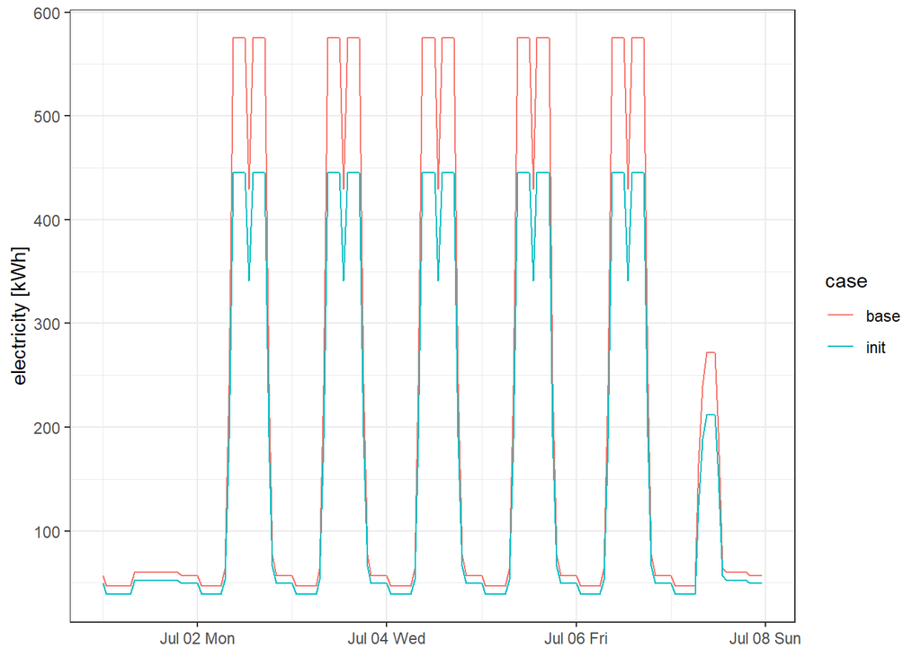

```r
# select one week in July to examine the discrepancy
meter_init %>% weekly_compare(7, 1)
```

## Calculate the statistical indicators

```r
# function to get the nmbe and cvrmse
cal_stats <- function(meter) {
    synthetic <- read_measured()
    c(nmbe = nmbe(meter$`electricity [kWh]`, synthetic$`electricity [kWh]`),
      cvrmse = cvrmse(meter$`electricity [kWh]`, synthetic$`electricity [kWh]`))
}
```

```r
stats_init <- meter_init %>% cal_stats()
```

Current calibration creteria in ASHRAE Guideline 14 for NMBE and CVRMSE is 10% and 30% respectively.